# T2 - Visualização de Dados

Esse gráfico de barras é uma ferramenta eficaz para comparar as taxas médias de homicídios entre as regiões do Brasil, facilitando a identificação de quais regiões apresentam as maiores e as menores taxas de violência. Com uma visualização clara e um design atraente, o gráfico permite uma compreensão rápida das disparidades regionais na segurança pública do país.

[output not shown]

[output cut: 16 more lines]

[output not shown]

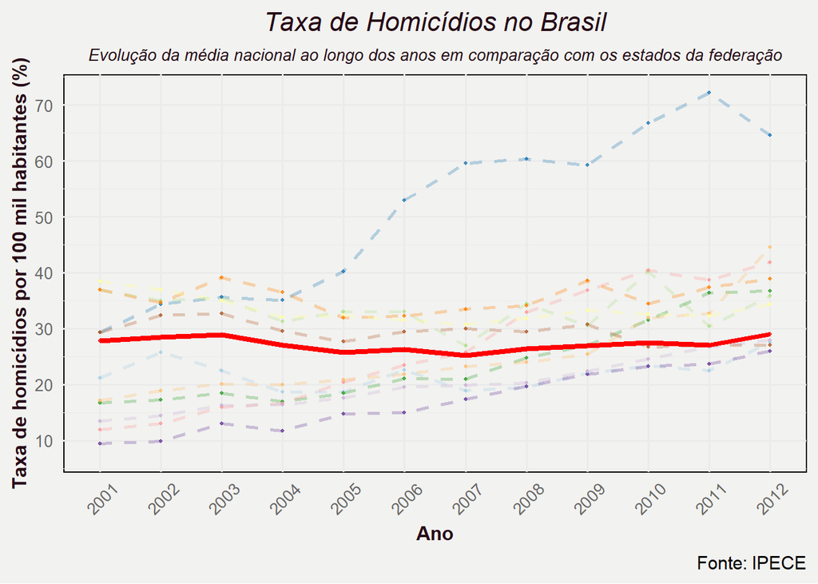

```r
ggplot(dados_estados, aes(x = as.character(ano), y = taxa, color = regiao, group = regiao)) +
  geom_line(size = 1, linetype = "dashed", alpha = 0.3) +
  geom_point(size = 0.8, alpha = 0.8) +
  labs(
    title = "Taxa de Homicídios no Brasil",
    subtitle = "Evolução da média nacional ao longo dos anos em comparação com os estados da federação",
    x = "Ano",
    y = "Taxa de homicídios por 100 mil habitantes (%)",
    caption = "Fonte: IPECE",
    color = "Região"
  ) +
  theme_minimal(base_size = 14) +
  theme(
    plot.title = element_text(hjust = 0.5, size = 16, face = "italic", color = "#270B17"),
    plot.subtitle = element_text(hjust = 0.5, size = 10, face = "italic", color = "#270B17"),
    plot.background = element_rect(fill = "#F2F2F0", color = NA),
    panel.background = element_rect(fill = "#F2F2F0"),
    axis.text.x = element_text(angle = 45, vjust = 0.6, size = 10, family = "Arial", face = "plain", color = "gray40"),
    axis.text.y = element_text(size = 10, family = "Arial", face = "plain", color = "gray40"),
    axis.title.x = element_text(size = 12, face = "bold", color = "#270B17"),
    axis.title.y = element_text(size = 12, face = "bold", color = "#270B17"),
    legend.position = "none"
  ) +
  scale_x_discrete() +
  scale_y_continuous(breaks = seq(0, 100, 10)) +
  scale_color_brewer(palette = "Paired") +
  geom_line(data = dados_estados %>% filter(regiao == "BRASIL"),
            aes(x = as.character(ano), y = taxa),
            color = "red", size = 1.5, linetype = "solid")
```

No eixo X, temos os anos, que são apresentados de forma discreta, enquanto no eixo Y está a taxa de homicídios por 100 mil habitantes, com intervalos de 10 unidades, permitindo uma visualização clara das variações ao longo do tempo. As linhas, apesar de finas e com opacidade reduzida para as regiões, permitem observar tendências e comparações entre elas de maneira eficaz. A linha nacional é destacada por sua cor vermelha e espessura maior, enfatizando a média nacional no contexto das outras regiões.

O título do gráfico, “Taxa de Homicídios no Brasil”, está centralizado e em itálico, acompanhado de um subtítulo explicativo que fornece mais contexto: “Evolução da média nacional ao longo dos anos em comparação com os estados da federação”. As informações de origem, com a legenda “Fonte: IPECE”, estão disponíveis na parte inferior como uma legenda de referência.

Além disso, o gráfico segue o estilo minimalista, com um fundo claro que não interfere na visualização das linhas e das informações. As etiquetas nos eixos estão bem posicionadas, e as variáveis estão suficientemente legíveis, facilitando a análise. A remoção da legenda também contribui para um design mais limpo, já que as cores estão diretamente associadas às regiões.

Esse gráfico é uma ferramenta poderosa para analisar a evolução da violência no Brasil, destacando as diferenças entre as regiões e colocando-as em perspectiva com a média nacional. Ele permite identificar períodos de maior ou menor violência, além de facilitar a comparação das tendências de cada região com a média do país.

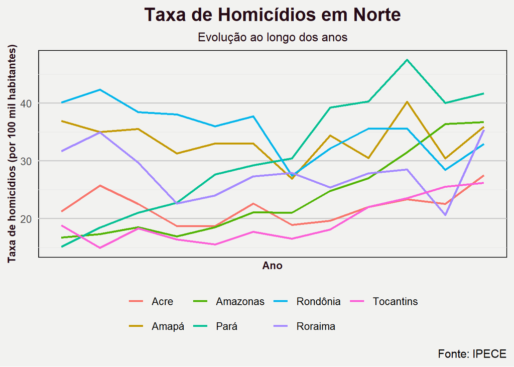

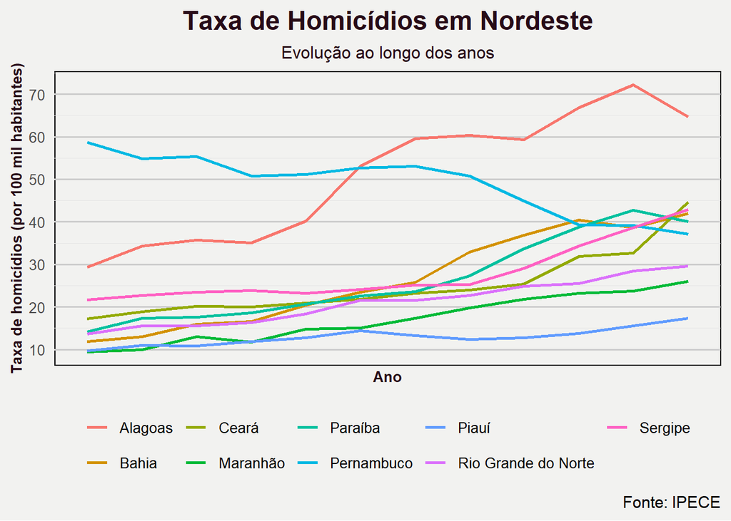

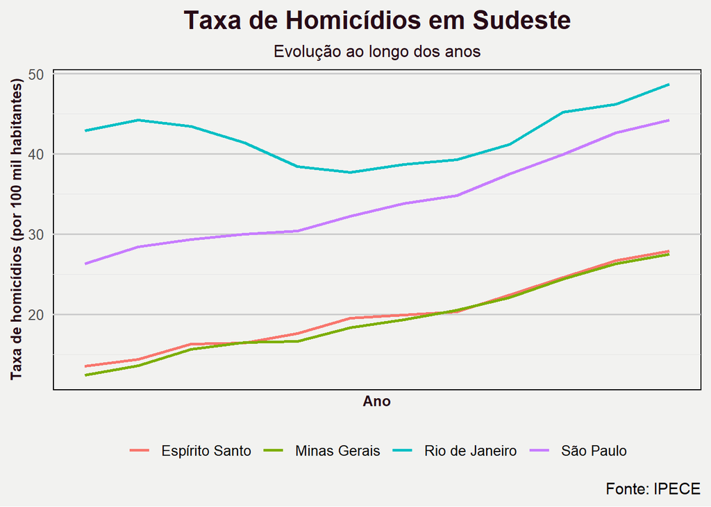

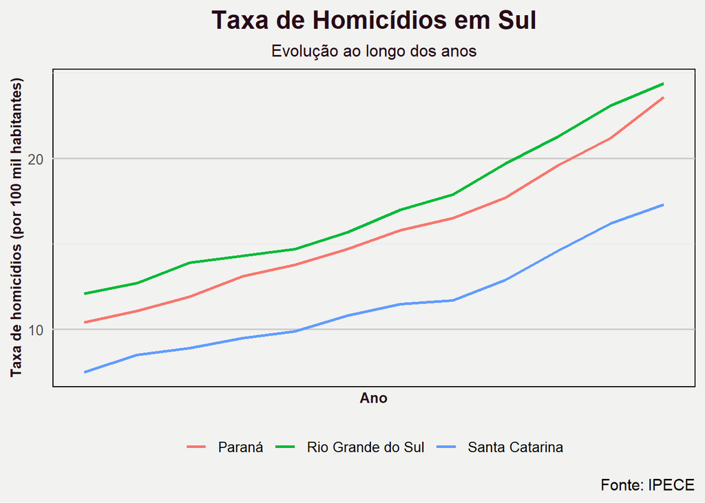

```
##
## $`Centro-Oeste`
```

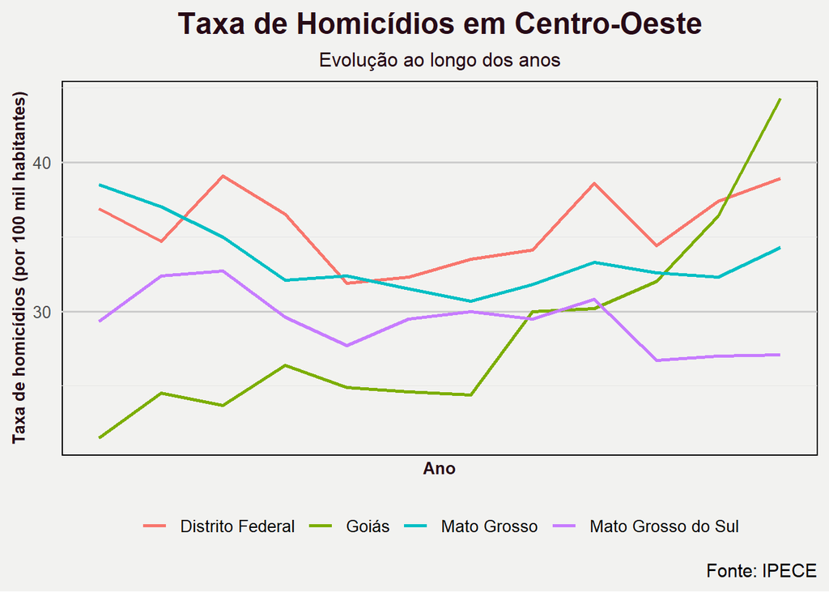

```r
# Para cada regiao no dataset, criar um gráfico separado
regioes <- unique(dados_estados_regiao$regiao)

# Lista para armazenar os gráficos
grafico_lista <- list()

for (regiao in regioes) {
  grafico_lista[[regiao]] <- ggplot(data = dados_estados_regiao %>% filter(regiao == !!regiao), aes(x = ano, y = taxa, color = estado)) +
    geom_line(size = 1) +
    scale_x_discrete() +
    scale_y_continuous(breaks = seq(0, 100, 10)) +
    labs(title = paste("Taxa de Homicídios em", regiao),
         subtitle = "Evolução ao longo dos anos",
         x = "Ano",
         y = "Taxa de homicídios (por 100 mil habitantes)",
         caption = "Fonte: IPECE",
         color = "Legenda") +
    theme_minimal(base_size = 14) +
    theme(
      plot.title = element_text(hjust = 0.5, size = 18, face = "bold", color = "#270B17"),
      plot.subtitle = element_text(hjust = 0.5, size = 12, color = "#270B17"),
      plot.background = element_rect(fill = "#F2F2F0", color = NA),
      panel.background = element_rect(fill = "#F2F2F0"),
      axis.text.x = element_text(angle = 45, vjust = 0.6, size = 10),
      axis.text.y = element_text(size = 10),
      axis.title.x = element_text(size = 10, face = "bold", color = "#270B17"),
      axis.title.y = element_text(size = 10, face = "bold", color = "#270B17"),
      axis.title = element_text(face = "bold"),
      legend.position = "bottom",
      legend.text = element_text(size = 10),
      legend.title = element_blank(),
      strip.text = element_text(size = 14, face = "bold"),
      panel.spacing = unit(1, "lines"),
      panel.grid.major = element_line(color = "grey80"),
      panel.grid.minor = element_line(color = "grey90")
    )}

grafico_lista
```

O código fornecido tem como objetivo criar gráficos individuais para cada uma das regiões do Brasil, ilustrando a evolução das taxas de homicídios ao longo dos anos. A primeira etapa consiste na extração das regiões únicas a partir do conjunto de dados `dados_estados_regiao`, utilizando a função `unique()`. Isso garante que o gráfico será gerado separadamente para cada região, permitindo uma análise detalhada por área geográfica.

Em termos de design, o gráfico utiliza um estilo minimalista, com o tema `theme_minimal()`, o que contribui para uma aparência limpa e objetiva. O gráfico conta com um fundo claro e linhas de grade discretas, o que facilita a leitura dos dados. O título do gráfico, que descreve a taxa de homicídios para cada região, é destacado em uma cor marrom escura (`#270B17`), e o subtítulo é formatado de forma a manter a coerência visual. A legenda, que indica os estados, é posicionada na parte inferior do gráfico, proporcionando uma organização clara e eficiente das informações.

Os gráficos são armazenados em uma lista chamada `grafico_lista`, e cada elemento dessa lista corresponde a um gráfico individual para uma das regiões. Essa estrutura facilita a análise comparativa entre as diferentes regiões do Brasil. Para visualizar esses gráficos, o código permite iterar sobre a lista e exibir cada gráfico separadamente, proporcionando uma análise visual clara das taxas de homicídios ao longo do tempo para cada região.

Por fim, esse processo de visualização de dados oferece uma maneira eficaz de observar as tendências das taxas de homicídios em diversas regiões brasileiras, permitindo comparações e insights sobre como as taxas variam ao longo dos anos e entre os estados.

## 2.2 b) EM BUSCA DAS RESPOSTAS:

### 2.2.4 Conclusão

A realização desta análise de dados me proporcionou uma compreensão mais profunda sobre como visualizar, explorar e interpretar dados complexos de forma eficiente. Durante o processo, identifiquei alguns padrões interessantes e surpreendentes, especialmente nas tendências de homicídios por região e nos estados com maiores variações ao longo do tempo. Isso confirmou a importância de tratar e analisar os dados com cuidado para evitar conclusões precipitadas baseadas em informações incompletas ou inconsistentes.

A visualização de dados vai além de simplesmente criar gráficos. Cada visualização tem um propósito específico e deve ser cuidadosamente escolhida para destacar insights importantes. A integração entre visualizações e anotações descritivas torna a análise mais compreensível e acessível, facilitando a comunicação dos resultados. Large Languange Models como o GPT foram usadas para auxiliar na descrição dos gráficos, pois ajuda a apresentar explicações claras e concisas, tornando o relatório mais didático e acessível para leitores com diferentes níveis de conhecimento técnico.

Concluímos que a análise exploratória dos dados como um primeiro passo essencial para entender o contexto dos dados antes de aplicar modelos mais complexos. A capacidade de interpretar os dados de forma eficaz, por meio de visualizações adequadas, é fundamental para a tomada de decisões informadas. Aqui, por exemplo, nota-se a urgência do Estado intervir na segurança pública do estado do Ceará, onde as ondas de violência estão se tornando cada vez mais frequentes.